# 232A - Project 1

Jiayu Wu

2018/1/21

## Problem 1

### 1

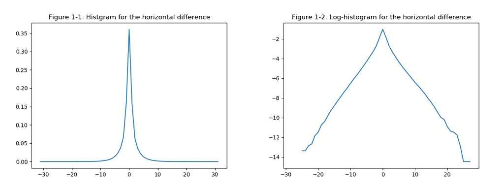

Figure 1-1 is the frequency histogram of horizontally gradient filtered grey level intensities for a natural image (image 1), figure 1-2 shows the logarithm of that histogram.

The histograms displays an symmetric distribution with a sharp peak near the center and a long tail, which reveals a high-order non-Gaussian structures. The log-plot has a peak and approximates a laplace distribution, which can be thought of as two exponential distributions spliced together back-to-back. It aligns with the intuitive perception that the intensity difference between two adjacent pixels in a natural image tend to be small, while a few sharp changes appears at the edge of the objects in the image.

### 2

The mean of the gradient filtered intensities is -0.0077657909, which is close to the median and mode 0. It implies that the distribution is centered at 0. The variance is 6.1359725.

The kurtosis is 6.57756615, which is rather high compared with that of gaussian ditribution. It verifies that the distribution of gradient filtered intensities is long tail.

### 3

Fit this histogram to a Generalized Gaussian distribution:
$$pdf: y=\frac{\gamma}{2\sigma\Gamma(1/\gamma)} \; e^{-(|z/\sigma|)^\gamma}$$
We get a quite satisfying fitted model:
$$pdf: y=\frac{0.78}{2 \times 1.06\Gamma(1/0.78)} \; e^{-(|z/1.06|)^{0.78}}$$
(Notes: the parameters are fitted by searching the parameters with least sum of squared residuals, and the sum of squared residuals was minimized to 0.00074.)

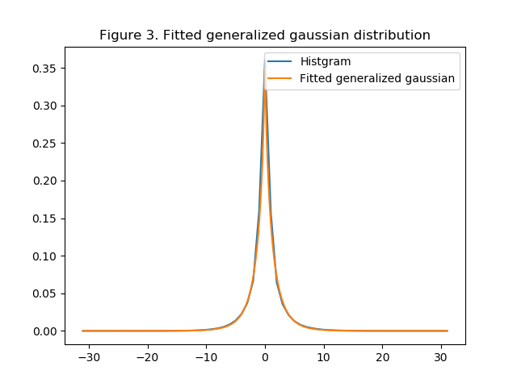

Figure 3 displays the fitted-curves super-imposed against the histogram. The shape parameter $\gamma = 0.78$. It is far from the shape parameter of gaussian distribution 2, which verifies the high-order non-gaussian structure of the distribution.

### 4

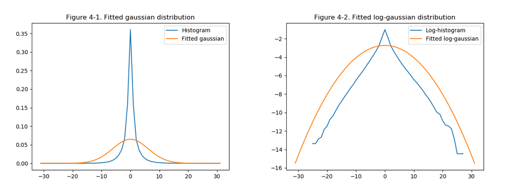

The sharp difference between the histogram and the gaussian distribution reveals that the distribution of gradient filtered intensities is non-gaussian with a dramatically heavier tail. From the log-plot, a difference in shape can be observed. Plot of log-gaussian density is smooth and bell-shaped, while the log-histogram has a peak and looks like two concave curves spliced together.

### 5

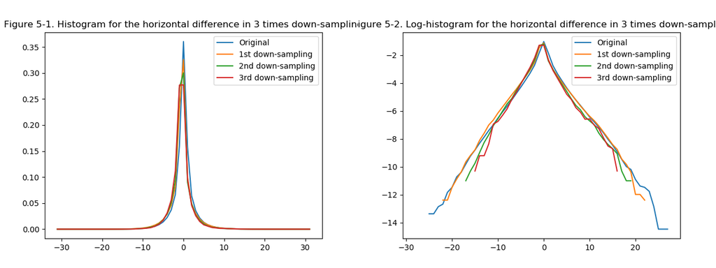

Figure 5-1 and 5-2 are histograms and log-histograms of the same image after 3 times down-sampling by averaging each $2 \times 2$ field. In this process, the distribution of gradient filtered intensities remains the same depite the reduction in the size and clarity of the image. It indicates that, the high-order non-gaussian structure we detected from above is invariant across different sizes of the natural image, and the information in the original image is actually redundant. Therefore, in practice we can reduce the data complexity before modeling, as the statistical properties won’t be blurred.

### 6

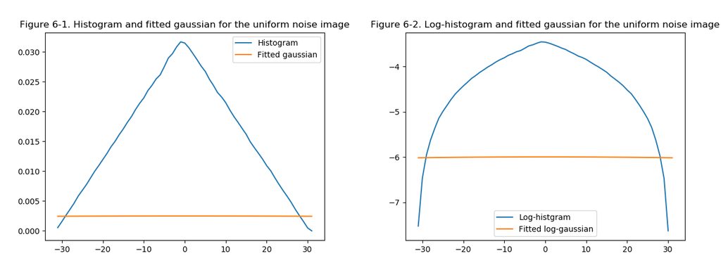

For a uniform noise image, the patterns and statistical properties we observed on natural images can not be reserved.

In this example, the mean of the gradient filtered intensities is still close to 0 (0.000267), while the variance is extremely large (160.2248) as the scale invariance does not holds, and there is no such high kurtosis (-0.60037344).